# Intro to R

(your name here)

1/19/2023

This is a brief intro to R and RStudio. Here are some good resources – VT library: The R Book, Michael J. Crawley, 2007  
– [bookdown](https://bookdown.org/josiesmith/labbook/basics-of-r.html#objects) R basics

## R as a calculator

```r
1+1
7*4
1753/18
2+5*3
(2+5)*3
```

```
## [1] 2
## [1] 28
## [1] 97.38889
## [1] 17
## [1] 21
```

## Scripts

When using R, it’s important that you are performing all operations by writing scripts of code to be run in R, rather than coding directly into the Console. Scripts allow you to save and modify your code as you move along, as well as go back to it later. You can open a script under File - New File - New R Script. Type your code directly into the script, and run individual lines of code either by clicking “Run” at the top of the script, or using the shortcut Cmd-Enter (Mac) / Ctrl-Enter (Windows).

You can annotate your code with information that helps you to understand each line by commenting after the symbol `#` in a code line.

```r
1+1 #this is a simple way to annotate; anything written after # will not be included in the code run
```

```
## [1] 2
```

## Types of data

There are many different types of data in R: values, vectors, matrices, dataframes, rasters, and more.

Before starting work in R, it can be useful to clear your environment so that any previous work sessions do not interfere with your current operations.

```r
object1 = data.frame()
```

```r
rm(list=ls())
```

### Objects

The simplest are objects - you can assign values to objects easily and perform calculations.

```r
x <- 6
2*x + 3
```

```
## [1] 15
```

```r
y <- 2
y^2
```

```
## [1] 4
```

### Functions

Functions simplify complex calculations and are the bread and butter of statistical analyses

```r
head(cars)
```

```
##   speed dist
## 1     4    2
## 2     4   10
## 3     7    4
## 4     7   22
## 5     8   16
## 6     9   10
```

```r
mean(cars$dist)
```

```
## [1] 42.98
```

### Vectors

You can also create vectors using the combine function `c()` A vector is a sequence of data that are of the same type

```r
x <- c(1,3,4,2,4,6,5) # integers or numerals
x
```

```
## [1] 1 3 4 2 4 6 5
```

```r
class(x)
```

```
## [1] "numeric"
```

```r
y <- c("a", "b", "c", "d") # characters
y
```

```
## [1] "a" "b" "c" "d"
```

```r
class(y)
```

```
## [1] "character"
```

### Indexing vectors

Within a vector, you can extract individual values based on their index, for example:

```r
x[1] #first value
x[3] #third value

y[2]
y[4]
```

```
## [1] 1
## [1] 4
## [1] "b"
## [1] "d"
```

To extract multiple values, you can either extract consecutive values using the colon, or by combining indices with c()

```r
x
x[2:5] #2nd, 3rd, 4th, and 5th values
x[c(2,4,7)] #2nd, 4th, and 7th values
```

```
## [1] 1 3 4 2 4 6 5
## [1] 3 4 2 4
## [1] 3 2 5
```

### Matrices

The next data type is matrices, which are 2-dimensional layouts of data. We can easily create these from a vector:

```r
vector.x <- c(4,7,2,8,5,3,8,0,6,4,2,7,6,9,3,1)
matrix.x <- matrix(vector.x,4,4) #4 rows, 4 columns
matrix.x2 <- matrix(vector.x,2,8) #2 rows, 8 columns
```

When specifying the number of rows and columns in R, rows come first.

```r
matrix.x[1,3] # [ROW,COLUMN]
```

```
## [1] 6
```

In the above code, R fills out the matrix of specified dimensions by column (default), so that in the above, a 4x4 matrix would contain, from top to bottom, the values 4,7,2,8 in the first column. If you’d like to fill out each row in order rather than column, that change is easily made.

```r
matrix.x3 <- matrix(vector.x,4,4,byrow=TRUE)


head(matrix.x) #filled out by column
```

```
##      [,1] [,2] [,3] [,4]
## [1,]    4    5    6    6
## [2,]    7    3    4    9
## [3,]    2    8    2    3
## [4,]    8    0    7    1
```

```r
head(matrix.x3) #filled out by row
```

```
##      [,1] [,2] [,3] [,4]
## [1,]    4    7    2    8
## [2,]    5    3    8    0
## [3,]    6    4    2    7
## [4,]    6    9    3    1
```

## Basic Statistics

You can run a wide range of basic statistics in R - here we examine vector x we just created:

```r
x
mean(x) # arithmetic mean
var(x) # variance
sd(x) #standard deviation
min(x) # minimum
max(x) # maximum
sum(x) # sum of all values
prod(x) # product of all values
median(x) # median
```

```
## [1] 1 3 4 2 4 6 5
## [1] 3.571429
## [1] 2.952381
## [1] 1.718249
## [1] 1
## [1] 6
## [1] 25
## [1] 2880
## [1] 4
```

## View summary

```r
summary(x) # summary statistics
```

```
##    Min. 1st Qu.  Median    Mean 3rd Qu.    Max.
##   1.000   2.500   4.000   3.571   4.500   6.000
```

```r
summary(matrix.x3)
```

```
##        V1             V2             V3             V4
##  Min.   :4.00   Min.   :3.00   Min.   :2.00   Min.   :0.00
##  1st Qu.:4.75   1st Qu.:3.75   1st Qu.:2.00   1st Qu.:0.75
##  Median :5.50   Median :5.50   Median :2.50   Median :4.00
##  Mean   :5.25   Mean   :5.75   Mean   :3.75   Mean   :4.00
##  3rd Qu.:6.00   3rd Qu.:7.50   3rd Qu.:4.25   3rd Qu.:7.25
##  Max.   :6.00   Max.   :9.00   Max.   :8.00   Max.   :8.00
```

## Data Frames

When multiple columns or vectors of data are combined, this is called a dataframe (think of data in spreadsheet form). Dataframes can be created manually or loaded into R using a spreadsheet in .csv format (more on this later).

### Writing Dataframes

First - We will write a simple dataset with mock catch data for a hypothetical fish species for the years 2010-2014.

```r
catchdata <- data.frame("year" = 2010:2014, "catch" = c(5000,5200,7100,4900,5150))
# year, catch = columns
head(catchdata)
```

```
##   year catch
## 1 2010  5000
## 2 2011  5200
## 3 2012  7100
## 4 2013  4900
## 5 2014  5150
```

### Merging data

Dataframes can be merged using the row bind `rbind()` function.

```r
# write another dataframe with same column names
catchdata2 <- data.frame("year"=c(2015:2019),  "catch"=c(4100,5700,3850,5500,4900))
head(catchdata2)
```

```
##   year catch
## 1 2015  4100
## 2 2016  5700
## 3 2017  3850
## 4 2018  5500
## 5 2019  4900
```

```r
alldata <- rbind(catchdata, catchdata2)
```

You can also combine columns of data using the column bind `cbind()` function.

### Saving dataframes

We can now save our new master dataframe as a .csv file as well, using the `write.csv()` command.

```r
write.csv(alldata, "alldata.csv")
```

Files will be saved to your working directory

## Setting a working directory and reading .csv files

### Setting a working directory

The working directory is the directory on your computer where R will retrieve and store data as well as save outputs such as plots and spreadsheets.

For this class, you should maintain a consistent file structure such that you can always code it. For example, on your local desktop, you might start a folder called “Fisheries Management”, with subfolders such as “Data”, “Figures”, “Scripts”, etc., so that you can easily tell R where to save and retrieve files. There are three ways to set your working directory, and we’ll cover all three, but it’s always best to code it (Option 3).

```
    |-- FisheriesManagement/                   <- root directory
        |-- Lab_1/
            |-- Lab1.Rmd
            |-- Lab1.R
            |-- alldata.csv
            |-- lab1_testdata.csv
        |-- Lab_2/
```

1. In the menu bar, click on “Session” and then select “Set Working Directory” from the drop-down menu. Select “Choose Directory…” and navigate to the desired folder.
2. In your pane with the following tabs: Files, Plots, Packages, Help, and Viewer (Default position is bottom right). After selecting “Files”, navigate to the desired folder and click “More” and then “Set as Working Directory”.
3. The command to set your working directory is `setwd()`. Everyone’s home directory will not be the same depending on where you put your root folder.

```r
getwd()
```

```
## [1] "/mnt/c/Users/jerem/Dropbox/FisheriesManagement2023/Lab1 - Intro to R part1"
```

```r
# You will have to change the setwd() function to specify your Fisheries Management Lab1 folder
setwd("~/../Fisheries Management/Data") # Mac
setwd("C:/../Fisheries Management/Data") # Windows
# press tab when filling out directories to see a list of options
setwd("../Lab1/")
```

### Reading a .csv file

Once you have set your working directory, you can read in the data using the `read.csv()` function.

```r
usa_landings <- read.csv("lab1_testdata.csv")
```

This dataset describes the total catch reported to the Food and Agriculture Organization (FAO) by the USA for the years 1950-2018.

```r
paste("Catch average:",mean(usa_landings$catch))
```

```
## [1] "Catch average: 3967149.96028986"
```

```r
paste("Catch standard deviation:",sd(usa_landings$catch))
```

```
## [1] "Catch standard deviation: 1165877.26111905"
```

```r
summary(usa_landings)
```

```
##       year          catch           country
##  Min.   :1950   Min.   :2311726   Length:69
##  1st Qu.:1967   1st Qu.:2772595   Class :character
##  Median :1984   Median :4229471   Mode  :character
##  Mean   :1984   Mean   :3967150
##  3rd Qu.:2001   3rd Qu.:4998490
##  Max.   :2018   Max.   :5694242
```

## Using Packages

R is an open source software, which means that users can create packages of functions for use by others. There are thousands of R packages available for different applications, including packages which are used specifically for analyzing fisheries data.

There are also several packages which are commonly used in many R operations, such as data management and plotting. We are going to install `tidyverse`, which is a collection of several frequently used packages including `ggplot`, `dplyr`, and `tidyr`. To install packages, there are several options - again, coding is the best.

1. Code it using `install.packages("tidyverse")`
2. In the menu bar, select “Tools” and then “Install Packages…”. Open source packages are found on the CRAN repository. Search for “tidyverse”.
3. In the inset window at the bottom right, select the “Packages” tab and then click “Install”. Search for “tidyverse” within the CRAN repository.

```r
# load the package
library(tidyverse)
```

### Subsetting Dataframes

We learned earlier to merge dataframes; alternatively, you can subset dataframes into smaller dataframes using the `subset()` function. Subset allows us to select rows from the dataframe where the value from a specific column meets a certain condition - for example, we can subset the larger dataframe to only include the years after 1980.

```r
usa_landings_post1980 <- subset(usa_landings, year>1980) # saves the subset as a new dataframe
head(usa_landings_post1980)
```

```
##    year   catch country
## 32 1981 3701137     USA
## 33 1982 3952683     USA
## 34 1983 4152983     USA
## 35 1984 4721775     USA
## 36 1985 4719868     USA
## 37 1986 4880950     USA
```

The use of operators such as `>`, `=`, `!`, etc. is extremely important in R, particularly when subsetting. A list of operators:

```r
x <- 5
y <- 10
x < y # less than
x <= y # less than or equal to
x > y # greater than
x >= y # greater than or equal to
x == y # is equal to
x != y #is not equal to
!x # is not x
x|y # x OR y
x&y # x AND y
isTRUE(x) # test if X is TRUE
isTRUE(TRUE)
```

Examples

```r
# Tip: run these functions one at a time instead of the whole chunk at once
subset(usa_landings, year==2007) #only 2007 data
subset(usa_landings, year!=2007) #everything EXCEPT the year 2007
subset(usa_landings, catch>=3000000) #years where catch was greater than or equal to 3 million tons
subset(usa_landings, year<1980 | year>=1990) #All years before 1980 and after 1989
subset(usa_landings, year>1980 & catch>=5000000) # All years after 1980 where catch was 5 million tons or greater
```

## Plotting in Base R

The Base R packages allow for some basic plotting through the `plot()` function. The default plot type will be a scatter plot. To plot the catches from our `usa_landings` dataframe, we can use the following code:

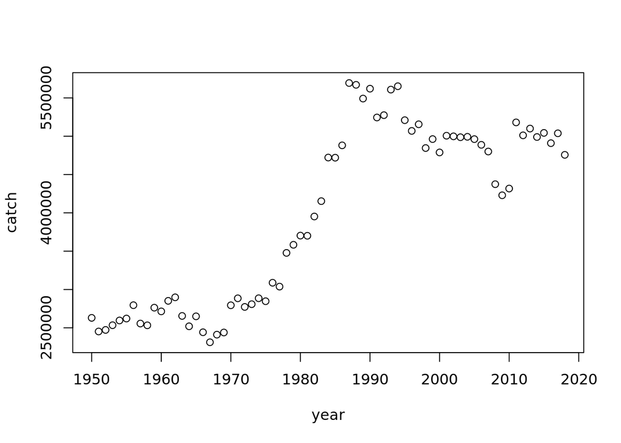

```r
plot(catch~year, data=usa_landings)
```

We can also code this as follows with the same result, using the `$` operator. The `$` operator allows us to specify a column from a dataframe such as `usa_landings`, so:

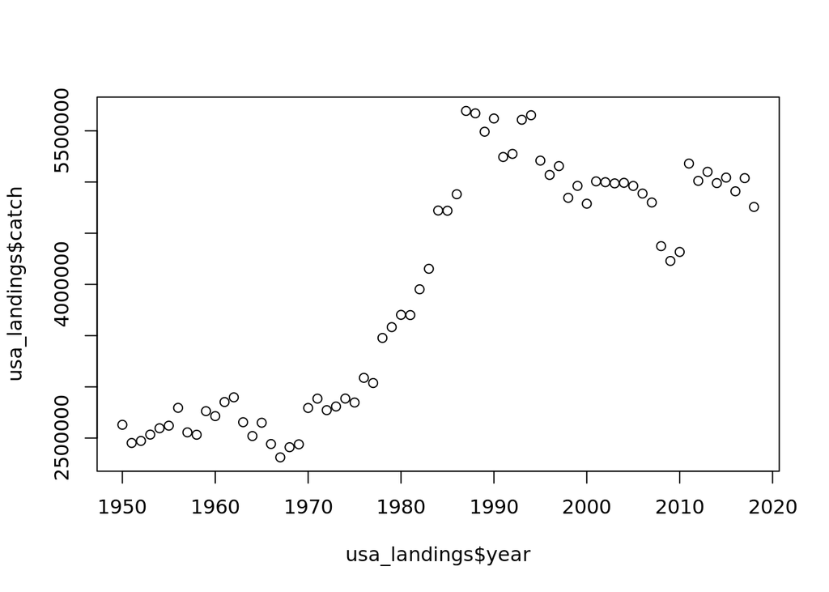

```r
plot(usa_landings$catch~usa_landings$year)
```

gives the same result as above.

NOTE: The `$` operator defines columns in a dataframe and can be very useful.

Now, see what else the `plot` function can do with `?plot`

```r
?plot
```

```
## Help on topic 'plot' was found in the following packages:
##
##   Package               Library
##   graphics              /usr/lib/R/library
##   base                  /usr/lib/R/library
##
##
## Using the first match ...
```

```r
# Select Generic X-Y Plotting and scroll down to see different arguments the function accepts
```

This works for all functions. We can see in this case that we can change the plot style; for example, we can create the same plot as a line plot

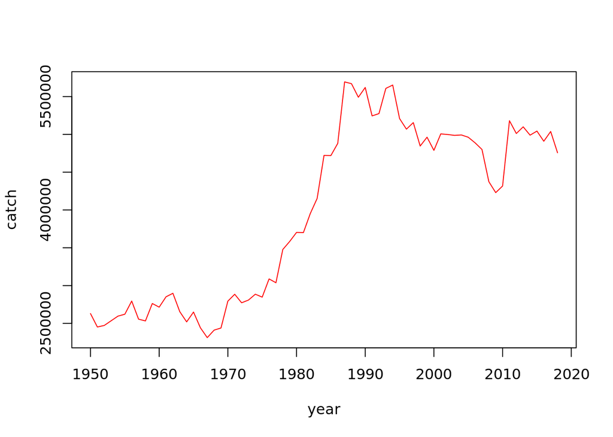

```r
plot(catch~year, data=usa_landings, type="l", col='red')
```

## Plotting in `ggplot`

`ggplot` is a commonly used package for plotting as it is highly customizable. Plots are created by defining `geom` objects, such as points, lines, or polygons. There are numerous ggplot guides available which discuss how different plot components can be customized.

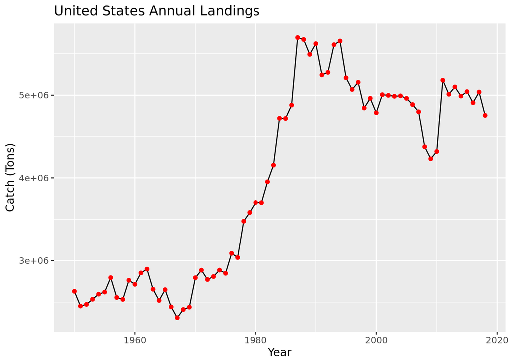

```r
ggplot(usa_landings) +
  geom_line(aes(x=year, y=catch)) + #creates the line plot
  geom_point(aes(x=year, y=catch), color="red") + #adds the red points
  ylab("Catch (Tons)") + #y axis title
  xlab("Year") + #x axis title
  ggtitle("United States Annual Landings") #main plot title
```

`ggplot` allows you to customize axes, labels, legends, line and shape styles, and most any other aspect of the plot you may want to modify. Look online at the available guides for additional information on plotting in ggplot.

[bookdown_ggplot](https://bookdown.org/rdpeng/RProgDA/basic-plotting-with-ggplot2.html)

## Using packages and functions to access data

Some packages are designed to allow the user to access databases and data through R for ease of analysis. Let’s take a look at `rfisheries` – you might need to install this with `install.packages("rfisheries")` in the console.

There are many ways to look at the data; first, let’s look at all reported catch in the FAO dataset. Here, we create a dataframe `annual.landings` with total annual landings for each year, using the `rfisheries` package.

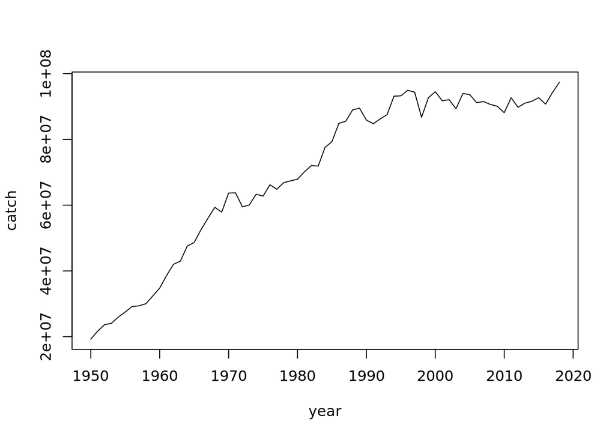

```r
# install.packages('rfisheries')
library(rfisheries)
annual.landings = of_landings()
plot(data=annual.landings, catch~year, type='l')
```

There are many options to produce data from `of_landings`, which we can see by looking at the help documents

```r
?of_landings
```

Next let’s look at a specific country. We first need to determine the country code for the country we want to analyze - we will use the United States.

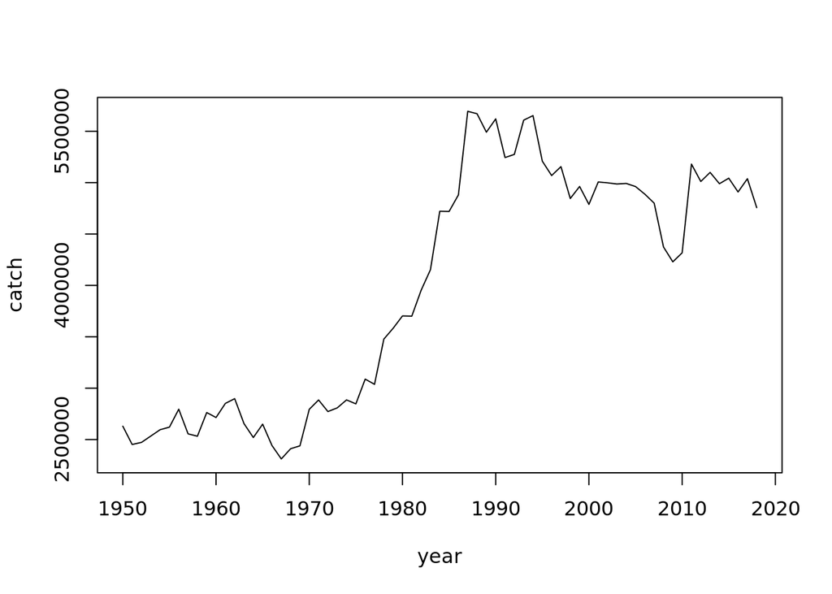

```r
countrycodes=of_country_codes() # can view this to see available country codes
annual.landings.usa = of_landings(country="USA")
plot(data=annual.landings.usa, catch~year, type='l')
```

We can also look at specific species - first, we need to identify the species code.

```r
species=rfisheries::of_species_codes()
head(species)
```

```
##          scientific_name   taxocode a3_code isscaap            english_name
## 1     Petromyzon marinus 1020100101     LAU      25             Sea lamprey
## 2   Lampetra fluviatilis 1020100201     LAR      25           River lamprey
## 3    Lampetra tridentata 1020100202     LAO      25         Pacific lamprey
## 4 Ichthyomyzon unicuspis 1020100401     LAY      25          Silver lamprey
## 5    Eudontomyzon mariae 1020100501     LAF      25 Ukrainian brook lamprey
## 6      Geotria australis 1020100701     LAE      25         Pouched lamprey
```

This returns a very long list. We can use the tools in `tidyverse` to filter this data out to a more usable format. Let’s say we are interested in landings of different `tuna` species. The following code will search the `species` dataframe for a partial match of the word “tuna” in the `english_name` column.

```r
tuna = species %>%
  filter(str_detect(english_name %>% tolower(), pattern = "tuna"))
head(tuna)
```

```
##            scientific_name      taxocode a3_code isscaap
## 1      Gymnosarda unicolor    1750101202     DOT      36
## 2            Auxis thazard    1750102301     FRI      36
## 3             Auxis rochei    1750102303     BLT      36
## 4 Auxis thazard, A. rochei 17501023XX018     FRZ      36
## 5       Katsuwonus pelamis    1750102501     SKJ      36
## 6          Thunnus thynnus    1750102601     BFT      36
##               english_name
## 1            Dogtooth tuna
## 2             Frigate tuna
## 3              Bullet tuna
## 4 Frigate and bullet tunas
## 5            Skipjack tuna
## 6    Atlantic bluefin tuna
```

Some notes on the above code:  
- `%>%` is called a pipe, and is an operator within the pacakge `dplyr`. It is used to chain commands together. The above code takes the dataframe `species` and then filters it for rows that have a partial match for the word “tuna”.  
- `filter()` usually requires a full text match. The `str_detect()` function allows us to use it for a partial match, so that we get all species of tuna.  
- Because R is case-sensitive, we use the `tolower()` command before searching.

The result is a dataframe called `tuna` which has the common name, scientific name, and species code for each species of tuna in the database. Let’s look at bigeye tuna - their code is “BET”. To isolate landings of bigeye tuna, we use the following code.

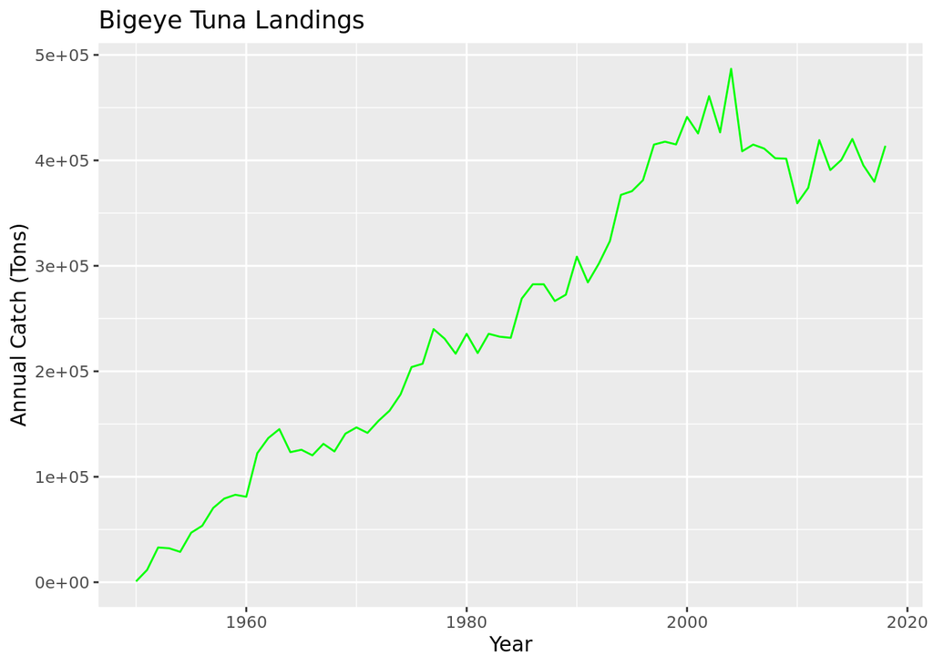

```r
BET_landings = of_landings(species="BET")
ggplot(BET_landings) +
  geom_line(aes(x=year, y=catch), col="green") +
  ylab("Annual Catch (Tons)")+
  xlab("Year")+
  ggtitle("Bigeye Tuna Landings")
```

Let’s repeat the process for blue sharks.

```r
blueshark = species %>%
  filter(str_detect(english_name %>% tolower(), pattern = "blue shark"))
head(blueshark)
```

Blue sharks code is “BSH”

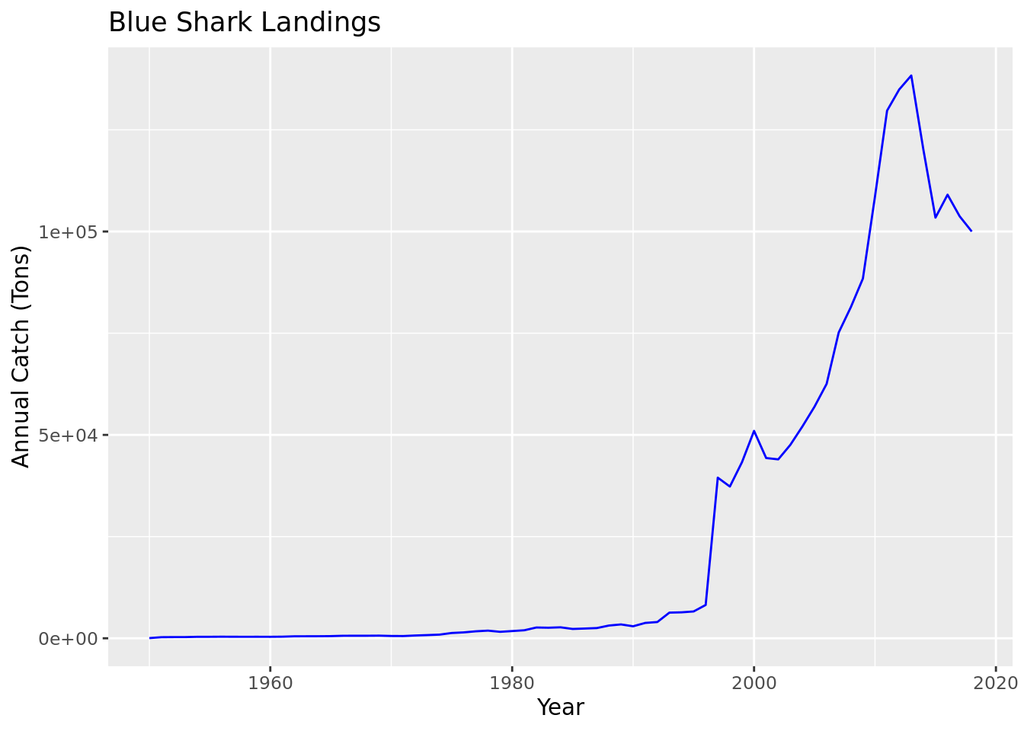

```r
BSH_landings = rfisheries::of_landings(species="BSH")
ggplot(BSH_landings) +
  geom_line(aes(x=year, y=catch), col="blue") +
  ylab("Annual Catch (Tons)")+
  xlab("Year")+
  ggtitle("Blue Shark Landings")
```

We can plot landings for the same two species together:

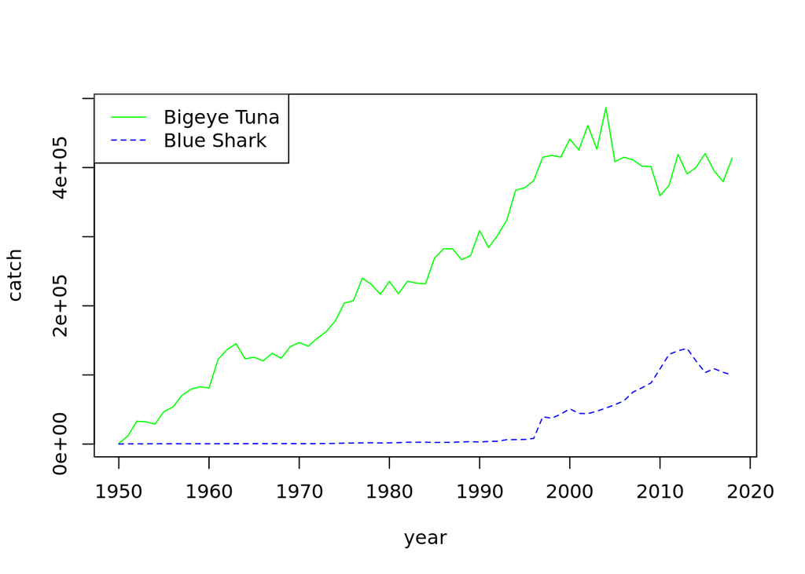

```r
plot(data=BET_landings, catch~year, type="l", col="green")
lines(data=BSH_landings, catch~year, col="blue", lty=2) #lty=2 is a dashed line
legend("topleft", legend=c("Bigeye Tuna", "Blue Shark"),
       lty=c(1,2), col=c("green","blue"))
```

We can combine the two dataframes into one

```r
landings=rbind(BET_landings,BSH_landings)
```

And plot in ggplot, using the column “species” as the group in order to differentiate between the data points.

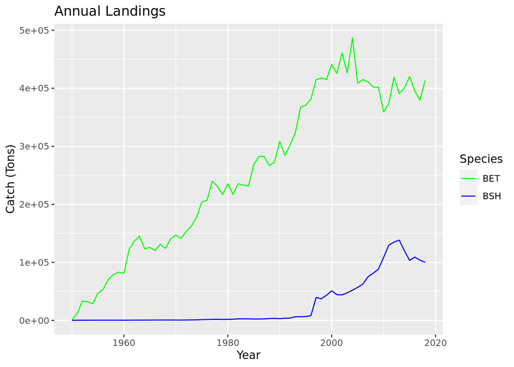

```r
ggplot(landings, aes(x=year, y=catch, group=species)) +
  geom_line(aes(color=species)) +
  scale_color_manual(values=c("green", "blue")) +
  ylab("Catch (Tons)") +
  xlab("Year") +
  ggtitle("Annual Landings") +
  labs(color="Species")
```

We will now break you into small groups to further explore the rfisheries data.

1. As a group, pick three or more countries and plot and describe the data. Make a plot of the data over time, with correctly labeled axes. Do some basic statistics. What is the mean catch? What is the mean catch for each decade? What is the variance?
2. Repeat the above with specific species (at least three). Summarize the data and plot the species on the same plot.
3. Combine the two problems above. Use what you’ve learned to look at the catches of one or more species in A SPECIFIC COUNTRY. For example, what do Atlantic bluefin tuna landings in England look like over the sample period?

NOTE: practice calculations in separate R script, and then present final data in this Rmarkdown file below. When you are done, Knit the project and view the HTML or PDF.